# IPCC AR6 WG1 Ch.6 Fig.19

## Initial steps

Add required libraries and tag scenarios to remove from datasets (per plots.py)

```r
suppressMessages(library(tidyverse))
suppressMessages(library(sf))
suppressMessages(library(tmap))
suppressMessages(library(spData))

# Unused scenarios
unused_scenarios <- c("SSP4-3.4-SPA4", "SSP4-6.0-SPA4", "SSP5-3.4-OS")
```

## Mapping countries to regions

### Preliminary mapping

From the file `country_mapping_ISO-5Regions.csv`, select only the three columns relevant per `plots.py` (adding “Country.Name” to check which countries are mapped where, and for making a map later).

Scroll down for an explanation.

```r
country_mapping <-
    read.csv("country_mapping_ISO-5Regions.csv") %>%
    select(c(Country.Name, current.region.defs, NEW.AR6.Ch6.Fig6.4))

country_mapping
```

| Country.Name | current.region.defs | NEW.AR6.Ch6.Fig6.4 |
| --- | --- | --- |
| Afghanistan | Southern Asia | South and South East Asia, Other Pacific |
| Albania | Europe | North America, Europe, Russia, Central Asia, and Pacific OECD |
| Algeria | Africa | Africa and Middle East |
| American Samoa | South-East Asia and Developing Pacific | South and South East Asia, Other Pacific |
| Angola | Africa | Africa and Middle East |
| Antigua and Barbuda | Latin America and Caribbean | Central and South America |
| Argentina | Latin America and Caribbean | Central and South America |
| Armenia | Eurasia | North America, Europe, Russia, Central Asia, and Pacific OECD |
| Aruba | Latin America and Caribbean | Central and South America |
| Australia | Asia-Pacific Developed | North America, Europe, Russia, Central Asia, and Pacific OECD |

[output cut: 209 more lines]

```r
region_mapping <-
    country_mapping %>%
    group_by(current.region.defs, NEW.AR6.Ch6.Fig6.4) %>%
    summarise(count = n()) %>%
    arrange(current.region.defs)
region_mapping
```

| current.region.defs | NEW.AR6.Ch6.Fig6.4 | count |
| --- | --- | --- |
| Africa | Africa and Middle East | 56 |
| Asia-Pacific Developed | North America, Europe, Russia, Central Asia, and Pacific OECD | 3 |
| Eastern Asia | East Asia | 5 |
| Eastern Asia | South and South East Asia, Other Pacific | 2 |
| Eurasia | North America, Europe, Russia, Central Asia, and Pacific OECD | 11 |
| Europe | North America, Europe, Russia, Central Asia, and Pacific OECD | 40 |
| Latin America and Caribbean | Central and South America | 46 |
| Middle East | Africa and Middle East | 14 |
| North America | Central and South America | 2 |
| North America | North America, Europe, Russia, Central Asia, and Pacific OECD | 3 |

[output cut: 3 more lines]

```r
region_mapping %>%
    select(!count) %>%
    summarise(count = n()) %>%
    arrange(desc(count))
```

| current.region.defs | count |
| --- | --- |
| Eastern Asia | 2 |
| North America | 2 |
| South-East Asia and Developing Pacific | 2 |
| Africa | 1 |
| Asia-Pacific Developed | 1 |
| Eurasia | 1 |
| Europe | 1 |
| Latin America and Caribbean | 1 |
| Middle East | 1 |
| Southern Asia | 1 |

### Choice of mapping “current.region.defs” to “NEW.AR6.Ch6.Fig6.4”

First we see the breakdown of the number of countries in each of the 5 “NEW.AR6.Ch6.Fig6.4” regions.

```r
country_mapping %>%
    select(!current.region.defs) %>%
    group_by(NEW.AR6.Ch6.Fig6.4) %>%
    summarise(count = n()) %>%
    arrange(desc(count))
```

| NEW.AR6.Ch6.Fig6.4 | count |
| --- | --- |
| Africa and Middle East | 70 |
| North America, Europe, Russia, Central Asia, and Pacific OECD | 57 |
| Central and South America | 48 |
| South and South East Asia, Other Pacific | 36 |
| East Asia | 8 |

```r
region_EA <-
    country_mapping %>%
    filter(current.region.defs == "Eastern Asia")

region_EA %>%
    filter(NEW.AR6.Ch6.Fig6.4 == "East Asia")
```

| Country.Name | current.region.defs | NEW.AR6.Ch6.Fig6.4 |
| --- | --- | --- |
| China | Eastern Asia | East Asia |
| Democratic Peoples Republic of Korea | Eastern Asia | East Asia |
| Hong Kong, China | Eastern Asia | East Asia |
| Macao | Eastern Asia | East Asia |
| Mongolia | Eastern Asia | East Asia |

```r
region_EA %>%
    filter(!NEW.AR6.Ch6.Fig6.4 == "East Asia")
```

| Country.Name | current.region.defs | NEW.AR6.Ch6.Fig6.4 |
| --- | --- | --- |
| Chinese Taipei | Eastern Asia | South and South East Asia, Other Pacific |
| Republic of Korea | Eastern Asia | South and South East Asia, Other Pacific |

```r
region_NA <-
    country_mapping %>%
    filter(current.region.defs == "North America")

region_NA %>%
    filter(NEW.AR6.Ch6.Fig6.4 == "Central and South America")
```

| Country.Name | current.region.defs | NEW.AR6.Ch6.Fig6.4 |
| --- | --- | --- |
| Bermuda | North America | Central and South America |
| Saint Pierre and Miquelon | North America | Central and South America |

```r
region_NA %>%
    filter(!NEW.AR6.Ch6.Fig6.4 == "Central and South America")
```

| Country.Name | current.region.defs | NEW.AR6.Ch6.Fig6.4 |
| --- | --- | --- |
| Canada | North America | North America, Europe, Russia, Central Asia, and Pacific OECD |
| Greenland | North America | North America, Europe, Russia, Central Asia, and Pacific OECD |
| United States | North America | North America, Europe, Russia, Central Asia, and Pacific OECD |

```r
region_SEA_DP <-
    country_mapping %>%
    filter(current.region.defs == "South-East Asia and Developing Pacific")

region_SEA_DP %>%
    filter(NEW.AR6.Ch6.Fig6.4 == "East Asia")
```

| Country.Name | current.region.defs | NEW.AR6.Ch6.Fig6.4 |
| --- | --- | --- |
| Cambodia | South-East Asia and Developing Pacific | East Asia |
| Laos | South-East Asia and Developing Pacific | East Asia |
| Vietnam | South-East Asia and Developing Pacific | East Asia |

```r
region_SEA_DP %>%
    filter(!NEW.AR6.Ch6.Fig6.4 == "East Asia")
```

| Country.Name | current.region.defs | NEW.AR6.Ch6.Fig6.4 |
| --- | --- | --- |
| American Samoa | South-East Asia and Developing Pacific | South and South East Asia, Other Pacific |
| Brunei Darussalam | South-East Asia and Developing Pacific | South and South East Asia, Other Pacific |
| Cook Islands | South-East Asia and Developing Pacific | South and South East Asia, Other Pacific |
| Federated States of Micronesia | South-East Asia and Developing Pacific | South and South East Asia, Other Pacific |
| Fiji | South-East Asia and Developing Pacific | South and South East Asia, Other Pacific |
| French Polynesia | South-East Asia and Developing Pacific | South and South East Asia, Other Pacific |
| Guam | South-East Asia and Developing Pacific | South and South East Asia, Other Pacific |
| Indonesia | South-East Asia and Developing Pacific | South and South East Asia, Other Pacific |
| Kiribati | South-East Asia and Developing Pacific | South and South East Asia, Other Pacific |
| Malaysia | South-East Asia and Developing Pacific | South and South East Asia, Other Pacific |

[output cut: 16 more lines]

## Regions on the map

Before showing the regions on a map, we first see if the names of the countries match between the two databases. Below you can see that they don’t for several countries (and some regions, such as “French Southern and Antarctic Lands”, which are absent in the IPCC database). For example, “Russian Federation” is “Russia” in the IPCC database, while “eSwatini” is “Swaziland” etc. Nevertheless, the map below shows the distribution of regions.

```r
world_ipcc <-
    left_join(world, country_mapping,
              by = join_by(name_long == Country.Name))

world_ipcc %>%
    select(name_long, NEW.AR6.Ch6.Fig6.4) %>%
    filter(is.na(NEW.AR6.Ch6.Fig6.4))
```

```
Simple feature collection with 18 features and 2 fields
Geometry type: MULTIPOLYGON
Dimension:     XY
Bounding box:  xmin: -180 ymin: -89.9 xmax: 180 ymax: 81.2504
Geodetic CRS:  WGS 84
```

|  | name_long | NEW.AR6.Ch6.Fig6.4 | geom |
| --- | --- | --- | --- |
| 1 | Democratic Republic of the Congo | NA |  |
| 2 | Russian Federation | NA |  |
| 3 | French Southern and Antarctic Lands | NA |  |
| 4 | Côte d'Ivoire | NA |  |
| 5 | Republic of the Congo | NA |  |
| 6 | eSwatini | NA |  |
| 7 | The Gambia | NA |  |
| 8 | Lao PDR | NA |  |
| 9 | Myanmar | NA |  |
| 10 | Dem. Rep. Korea | NA |  |

[output cut: 8 more lines]

```
Some legend labels were too wide. These labels have been resized to 0.48. Increase legend.width (argument of tm_layout) to make the legend wider and therefore the labels larger.
```

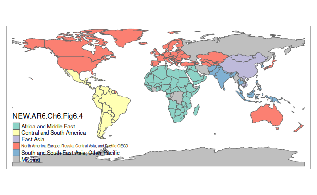

```r
tm_shape(world_ipcc) +
    tm_fill(col = "NEW.AR6.Ch6.Fig6.4") +
    tm_borders()
```

## Databases of global and regional emissions

### Global emissions

Below you can see the variables from the database, the number of rows (observations), the models used, the scenarios considered and the breakdown of variables.

```r
emissions_global <-
    read.csv("ar6-wg1-ch6-emissions-global-data.csv") %>%
    filter(!Scenario %in% unused_scenarios)

cols_global <- colnames(emissions_global)
cols_global
```

```
  [1] "Model"    "Scenario" "Region"   "Variable" "Unit"     "X1850"
  [7] "X1851"    "X1852"    "X1853"    "X1854"    "X1855"    "X1856"
 [13] "X1857"    "X1858"    "X1859"    "X1860"    "X1861"    "X1862"
 [19] "X1863"    "X1864"    "X1865"    "X1866"    "X1867"    "X1868"
 [25] "X1869"    "X1870"    "X1871"    "X1872"    "X1873"    "X1874"
 [31] "X1875"    "X1876"    "X1877"    "X1878"    "X1879"    "X1880"
 [37] "X1881"    "X1882"    "X1883"    "X1884"    "X1885"    "X1886"
 [43] "X1887"    "X1888"    "X1889"    "X1890"    "X1891"    "X1892"
 [49] "X1893"    "X1894"    "X1895"    "X1896"    "X1897"    "X1898"
 [55] "X1899"    "X1900"    "X1901"    "X1902"    "X1903"    "X1904"
 [61] "X1905"    "X1906"    "X1907"    "X1908"    "X1909"    "X1910"
 [67] "X1911"    "X1912"    "X1913"    "X1914"    "X1915"    "X1916"
 [73] "X1917"    "X1918"    "X1919"    "X1920"    "X1921"    "X1922"
 [79] "X1923"    "X1924"    "X1925"    "X1926"    "X1927"    "X1928"
 [85] "X1929"    "X1930"    "X1931"    "X1932"    "X1933"    "X1934"
```

[output cut: 16 more lines]

```r
nrow(emissions_global)
```

```
[1] 807
```

```r
unique(emissions_global$Model)
```

```
 [1] "AIM/CGE"         "CMIP5"           "CMIP6"
 [4] "EDGAR"           "Ev5a"            "GAINS"
 [7] "History"         "IMAGE"           "MESSAGE-GLOBIOM"
[10] "RCP"             "REMIND-MAGPIE"
```

```r
unique(emissions_global$Scenario)
```

```
 [1] "SSP3-7.0-SPA0"       "SSP3-LowNTCF"        "History"
 [4] "CLE"                 "MTFR"                "SLCF"
 [7] "GAINS-CLE"           "GAINS-KA"            "GAINS-MTFR"
[10] "Velders-(2015) high" "Velders-(2015) low"  "ECLIPSE_Ev5a"
[13] "EDGAR"               "SSP1-1.9-SPA1"       "SSP1-2.6-SPA1"
[16] "SSP2-4.5-SPA2"       "RCP 2.6"             "RCP 4.5"
[19] "RCP 6.0"             "RCP 8.5"             "RCP3-PD(2.6)"
[22] "RCP4.5"              "RCP6.0"              "RCP8.5"
[25] "SSP5-8.5"
```

```r
unique(emissions_global$Region)
```

```
[1] "World"
```

```r
unique(emissions_global$Variable)
```

```
  [1] "Emissions|BC"
  [2] "Emissions|BC|Agricultural Waste Burning"
  [3] "Emissions|BC|Aircraft"
  [4] "Emissions|BC|Energy Sector"
  [5] "Emissions|BC|Forest Burning"
  [6] "Emissions|BC|Grassland Burning"
  [7] "Emissions|BC|Industrial Sector"
  [8] "Emissions|BC|International Shipping"
  [9] "Emissions|BC|Peat Burning"
 [10] "Emissions|BC|Residential Commercial Other"
 [11] "Emissions|BC|Transportation Sector"
 [12] "Emissions|BC|Waste"
 [13] "Emissions|C2F6"
 [14] "Emissions|CF4"
 [15] "Emissions|CH4"
```

[output cut: 100 more lines]

### Regional emissions

The same information as above is shown here, but for regional emissions from the file `ar6-wg1-ch6-emissions-regional-data-5regions.csv`.

```r
# N.B.: Uses five regions
emissions_regional <-
    read.csv("ar6-wg1-ch6-emissions-regional-data-5regions.csv") %>%
    filter(!Scenario %in% unused_scenarios)

cols_regional <- colnames(emissions_regional)
cols_regional
```

```
  [1] "Model"    "Scenario" "Region"   "Variable" "Unit"     "X1850"
  [7] "X1851"    "X1852"    "X1853"    "X1854"    "X1855"    "X1856"
 [13] "X1857"    "X1858"    "X1859"    "X1860"    "X1861"    "X1862"
 [19] "X1863"    "X1864"    "X1865"    "X1866"    "X1867"    "X1868"
 [25] "X1869"    "X1870"    "X1871"    "X1872"    "X1873"    "X1874"
 [31] "X1875"    "X1876"    "X1877"    "X1878"    "X1879"    "X1880"
 [37] "X1881"    "X1882"    "X1883"    "X1884"    "X1885"    "X1886"
 [43] "X1887"    "X1888"    "X1889"    "X1890"    "X1891"    "X1892"
 [49] "X1893"    "X1894"    "X1895"    "X1896"    "X1897"    "X1898"
 [55] "X1899"    "X1900"    "X1901"    "X1902"    "X1903"    "X1904"
 [61] "X1905"    "X1906"    "X1907"    "X1908"    "X1909"    "X1910"
 [67] "X1911"    "X1912"    "X1913"    "X1914"    "X1915"    "X1916"
 [73] "X1917"    "X1918"    "X1919"    "X1920"    "X1921"    "X1922"
 [79] "X1923"    "X1924"    "X1925"    "X1926"    "X1927"    "X1928"
 [85] "X1929"    "X1930"    "X1931"    "X1932"    "X1933"    "X1934"
 [91] "X1935"    "X1936"    "X1937"    "X1938"    "X1939"    "X1940"
 [97] "X1941"    "X1942"    "X1943"    "X1944"    "X1945"    "X1946"
[103] "X1947"    "X1948"    "X1949"    "X1950"    "X1951"    "X1952"
[109] "X1953"    "X1954"    "X1955"    "X1956"    "X1957"    "X1958"
[115] "X1959"    "X1960"    "X1961"    "X1962"    "X1963"    "X1964"
[121] "X1965"    "X1966"    "X1967"    "X1968"    "X1969"    "X1970"
[127] "X1971"    "X1972"    "X1973"    "X1974"    "X1975"    "X1976"
[133] "X1977"    "X1978"    "X1979"    "X1980"    "X1981"    "X1982"
[139] "X1983"    "X1984"    "X1985"    "X1986"    "X1987"    "X1988"
[145] "X1989"    "X1990"    "X1991"    "X1992"    "X1993"    "X1994"
[151] "X1995"    "X1996"    "X1997"    "X1998"    "X1999"    "X2000"
[157] "X2001"    "X2002"    "X2003"    "X2004"    "X2005"    "X2006"
[163] "X2007"    "X2008"    "X2009"    "X2010"    "X2011"    "X2012"
[169] "X2013"    "X2014"    "X2015"    "X2020"    "X2030"    "X2040"
[175] "X2050"    "X2060"    "X2070"    "X2080"    "X2090"    "X2100"
```

```r
nrow(emissions_regional)
```

```
[1] 4565
```

```r
unique(emissions_regional$Model)
```

```
[1] "AIM"             "CMIP5"           "CMIP6"           "History"
[5] "IMAGE"           "MESSAGE-GLOBIOM" "RCP"             "REMIND-MAGPIE"
```

```r
unique(emissions_regional$Scenario)
```

```
 [1] "SSP3-7.0-SPA0" "SSP3-LowNTCF"  "History"       "CEDS"
 [5] "SSP1-1.9-SPA1" "SSP1-2.6-SPA1" "SSP2-4.5-SPA2" "RCP 2.6"
 [9] "RCP 4.5"       "RCP 6.0"       "RCP 8.5"       "SSP5-8.5"
```

```r
unique(emissions_regional$Region)
```

```
[1] "Africa and Middle East"
[2] "Central and South America"
[3] "East Asia"
[4] "North America, Europe, Russia, Central Asia, and Pacific OECD"
[5] "South and South East Asia, Other Pacific"
```

```r
unique(emissions_regional$Variable)
```

```
  [1] "Emissions|BC"
  [2] "Emissions|BC|Agricultural Waste Burning"
  [3] "Emissions|BC|Agriculture"
  [4] "Emissions|BC|Energy Sector"
  [5] "Emissions|BC|Forest Burning"
  [6] "Emissions|BC|Grassland Burning"
  [7] "Emissions|BC|Industrial Sector"
  [8] "Emissions|BC|Peat Burning"
  [9] "Emissions|BC|Residential Commercial Other"
 [10] "Emissions|BC|Solvents Production and Application"
 [11] "Emissions|BC|Transportation Sector"
 [12] "Emissions|BC|Waste"
 [13] "Emissions|CH4"
 [14] "Emissions|CH4|Agricultural Waste Burning"
 [15] "Emissions|CH4|Agriculture"
```

[output cut: 107 more lines]

### Comparing global and regional databases

While the database of global emissions has 184 variables, that for regional emissions only has 180. Below we see which variables are missing from the latter.

```r
janitor::compare_df_cols(emissions_global, emissions_regional) %>%
    filter(is.na(emissions_regional))
```

| column_name | emissions_global | emissions_regional |
| --- | --- | --- |
| X2016 | numeric | NA |
| X2017 | numeric | NA |
| X2018 | numeric | NA |
| X2019 | numeric | NA |

### Comparing two CSV files of regional data

The IPCC has provided two seemingly identical databases with different names: `ar6-wg1-ch6-emissions-regional-data-5regions.csv` and `ar6-wg1-ch6-emissions-regional-data.csv`. Initially, it seemed like the latter had more granular information about the regions (perhaps mapped to “current.region.defs”), but this is not the case: it has the same region names as the other file. Further exploration shows some differences between the two files, as shown below.

```r
emissions_current_regions <-
    read.csv("ar6-wg1-ch6-emissions-regional-data.csv") %>%
    filter(!Scenario %in% unused_scenarios)
# %>%
#   rename(Current_Region = Region)

unique(emissions_current_regions$Region)
```

```
[1] "Africa and Middle East"
[2] "Central and South America"
[3] "East Asia"
[4] "North America, Europe, Russia, Central Asia, and Pacific OECD"
[5] "South and South East Asia, Other Pacific"
```

```r
summary(arsenal::comparedf(emissions_current_regions, emissions_regional))
```

Summary of data.frames

| version | arg | ncol | nrow |
| --- | --- | --- | --- |
| x | emissions_current_regions | 180 | 4565 |
| y | emissions_regional | 180 | 4565 |

```
NA
```

Summary of overall comparison

| statistic | value |
| --- | --- |
| Number of by-variables | 0 |
| Number of non-by variables in common | 180 |
| Number of variables compared | 180 |
| Number of variables in x but not y | 0 |
| Number of variables in y but not x | 0 |
| Number of variables compared with some values unequal | 175 |
| Number of variables compared with all values equal | 5 |
| Number of observations in common | 4565 |
| Number of observations in x but not y | 0 |
| Number of observations in y but not x | 0 |
| Number of observations with some compared variables unequal | 2272 |
| Number of observations with all compared variables equal | 2293 |
| Number of values unequal | 29518 |

```
NA
```

Variables not shared

| No variables not shared |
| --- |

```
NA
```

Other variables not compared

| No other variables not compared |
| --- |

```
NA
```

Observations not shared

| No observations not shared |
| --- |

```
NA
```

Differences detected by variable

| var.x | var.y | n | NAs |
| --- | --- | --- | --- |
| Model | Model | 0 | 0 |
| Scenario | Scenario | 0 | 0 |
| Region | Region | 0 | 0 |
| Variable | Variable | 0 | 0 |
| Unit | Unit | 0 | 0 |
| X1850 | X1850 | 30 | 0 |
| X1851 | X1851 | 28 | 0 |
| X1852 | X1852 | 28 | 0 |
| X1853 | X1853 | 28 | 0 |
| X1854 | X1854 | 28 | 0 |
| X1855 | X1855 | 28 | 0 |
| X1856 | X1856 | 28 | 0 |
| X1857 | X1857 | 28 | 0 |
| X1858 | X1858 | 28 | 0 |
| X1859 | X1859 | 28 | 0 |
| X1860 | X1860 | 30 | 0 |
| X1861 | X1861 | 28 | 0 |
| X1862 | X1862 | 28 | 0 |
| X1863 | X1863 | 28 | 0 |
| X1864 | X1864 | 28 | 0 |
| X1865 | X1865 | 28 | 0 |
| X1866 | X1866 | 28 | 0 |
| X1867 | X1867 | 28 | 0 |
| X1868 | X1868 | 28 | 0 |
| X1869 | X1869 | 28 | 0 |
| X1870 | X1870 | 30 | 0 |
| X1871 | X1871 | 28 | 0 |
| X1872 | X1872 | 28 | 0 |
| X1873 | X1873 | 28 | 0 |
| X1874 | X1874 | 28 | 0 |

[output cut: 150 more lines]

```
NA
```

Differences detected (29468 not shown)

| var.x | var.y | ..row.names.. | values.x | values.y | row.x | row.y |
| --- | --- | --- | --- | --- | --- | --- |
| X1850 | X1850 | 1229 | 0.1505004 | 0.1504872 | 1229 | 1229 |
| X1850 | X1850 | 1253 | 22.50398 | 22.50319 | 1253 | 1253 |
| X1850 | X1850 | 1277 | 0.5179229 | 0.5176253 | 1277 | 1277 |
| X1850 | X1850 | 1300 | 0.9042424 | 0.9042411 | 1300 | 1300 |
| X1850 | X1850 | 1312 | 1.046345 | 1.046293 | 1312 | 1312 |
| X1850 | X1850 | 1324 | 0.1680475 | 0.1680454 | 1324 | 1324 |
| X1850 | X1850 | 1336 | 4.115626 | 4.115514 | 1336 | 1336 |
| X1850 | X1850 | 1337 | 0.4094407 | 0.3228789 | 1337 | 1337 |
| X1850 | X1850 | 1349 | 5.189415 | 4.260081 | 1349 | 1349 |
| X1850 | X1850 | 1361 | 53.58271 | 38.89107 | 1361 | 1361 |
| X1851 | X1851 | 1229 | 0.1501614 | 0.1501485 | 1229 | 1229 |
| X1851 | X1851 | 1253 | 22.42899 | 22.42821 | 1253 | 1253 |
| X1851 | X1851 | 1277 | 0.5197037 | 0.5194107 | 1277 | 1277 |
| X1851 | X1851 | 1300 | 0.9009933 | 0.900992 | 1300 | 1300 |
| X1851 | X1851 | 1312 | 1.043122 | 1.043071 | 1312 | 1312 |
| X1851 | X1851 | 1324 | 0.1691642 | 0.1691622 | 1324 | 1324 |
| X1851 | X1851 | 1336 | 4.100179 | 4.100069 | 1336 | 1336 |
| X1851 | X1851 | 1337 | 0.4064968 | 0.3199004 | 1337 | 1337 |
| X1851 | X1851 | 1361 | 53.18587 | 38.49895 | 1361 | 1361 |
| X1851 | X1851 | 1385 | 2.256342 | 2.04618 | 1385 | 1385 |
| X1852 | X1852 | 1229 | 0.149141 | 0.1491282 | 1229 | 1229 |
| X1852 | X1852 | 1253 | 22.22951 | 22.22874 | 1253 | 1253 |
| X1852 | X1852 | 1277 | 0.5200344 | 0.5197443 | 1277 | 1277 |
| X1852 | X1852 | 1300 | 0.8920096 | 0.8920084 | 1300 | 1300 |
| X1852 | X1852 | 1312 | 1.034633 | 1.034582 | 1312 | 1312 |
| X1852 | X1852 | 1324 | 0.1695278 | 0.1695258 | 1324 | 1324 |
| X1852 | X1852 | 1336 | 4.059667 | 4.059557 | 1336 | 1336 |
| X1852 | X1852 | 1337 | 0.402734 | 0.3172693 | 1337 | 1337 |
| X1852 | X1852 | 1361 | 52.6472 | 38.16506 | 1361 | 1361 |
| X1852 | X1852 | 1385 | 2.240239 | 2.032107 | 1385 | 1385 |
| X1853 | X1853 | 1229 | 0.1494289 | 0.1494161 | 1229 | 1229 |
| X1853 | X1853 | 1253 | 22.24423 | 22.24346 | 1253 | 1253 |
| X1853 | X1853 | 1277 | 0.523373 | 0.5230808 | 1277 | 1277 |
| X1853 | X1853 | 1300 | 0.8918505 | 0.8918492 | 1300 | 1300 |
| X1853 | X1853 | 1312 | 1.036115 | 1.036064 | 1312 | 1312 |
| X1853 | X1853 | 1324 | 0.1712046 | 0.1712026 | 1324 | 1324 |
| X1853 | X1853 | 1336 | 4.059909 | 4.059798 | 1336 | 1336 |
| X1853 | X1853 | 1337 | 0.4006968 | 0.315039 | 1337 | 1337 |
| X1853 | X1853 | 1361 | 52.4047 | 37.90016 | 1361 | 1361 |
| X1853 | X1853 | 1385 | 2.227885 | 2.01911 | 1385 | 1385 |
| X1854 | X1854 | 1229 | 0.1501585 | 0.1501456 | 1229 | 1229 |
| X1854 | X1854 | 1253 | 22.33223 | 22.33145 | 1253 | 1253 |
| X1854 | X1854 | 1277 | 0.5276405 | 0.5273462 | 1277 | 1277 |
| X1854 | X1854 | 1300 | 0.894728 | 0.8947267 | 1300 | 1300 |
| X1854 | X1854 | 1312 | 1.041123 | 1.041072 | 1312 | 1312 |
| X1854 | X1854 | 1324 | 0.1733496 | 0.1733476 | 1324 | 1324 |
| X1854 | X1854 | 1336 | 4.074119 | 4.074007 | 1336 | 1336 |
| X1854 | X1854 | 1337 | 0.3980772 | 0.3126279 | 1337 | 1337 |
| X1854 | X1854 | 1361 | 52.06323 | 37.60535 | 1361 | 1361 |
| X1854 | X1854 | 1385 | 2.214194 | 2.005584 | 1385 | 1385 |

```
NA
```

Non-identical attributes

| No non-identical attributes |
| --- |

```
NA
```

## Comparing emission types

Based on the below graph (and the ones in the sections below), it appears that the emissions recorded by just the name of the chemical are the aggregate value of the individual contributing factors.

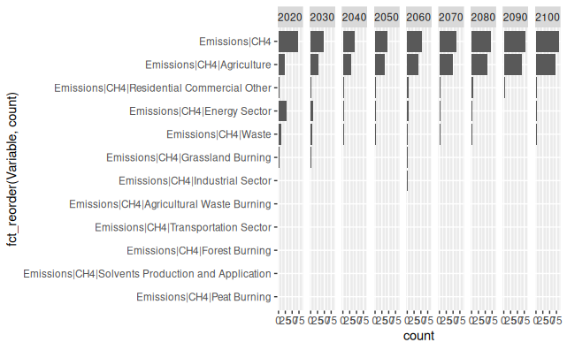

```r
emissions_regional %>%
    filter(grepl("CH4", Variable)) %>%
    filter(Region == "Africa and Middle East") %>%
    filter(Model == "AIM") %>%
    filter(grepl("LowNTCF", Scenario)) %>%
    select(!Model) %>%
    select(!Scenario) %>%
    select(!Region) %>%
    select(!Unit) %>%
    rename_with(~ str_remove(., "X"), everything()) %>%
    pivot_longer(
        cols = "1850":"2100",
        names_to = "year",
        values_to = "count"
    ) %>%
    mutate(year = as.Date(year, format = "%Y")) %>%
    mutate(year = as.numeric(format(year, "%Y"))) %>%
    filter(year >= 2020) %>%
    #select(!year) %>%
    ggplot() +
    geom_col(aes(count, fct_reorder(Variable, count))) +
    facet_grid(cols = vars(year))
```

## Reproduction of graphics

First we look at methane emissions in Africa and the Middle East, to compare with the top-left plot from the [original figure](https://www.ipcc.ch/report/ar6/wg1/downloads/figures/IPCC_AR6_WGI_Figure_6_19.png).

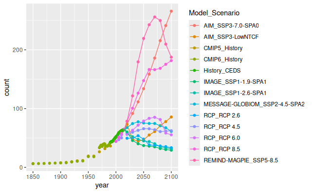

```r
emissions_regional %>%
    filter(Variable == "Emissions|CH4") %>%
    select(!Variable) %>%
    filter(Region == "Africa and Middle East") %>%
    select(!Region) %>%
    select(!Unit) %>%
    unite(Model_Scenario, c("Model", "Scenario")) %>%
    rename_with(~ str_remove(., "X"), everything()) %>%
    pivot_longer(
        cols = "1850":"2100",
        names_to = "year",
        values_to = "count"
    ) %>%
    mutate(year = as.Date(year, format = "%Y")) %>%
    mutate(year = as.numeric(format(year, "%Y"))) %>%
    ggplot() +
    geom_point(aes(x = year, y = count, colour = Model_Scenario)) +
    geom_line(aes(x = year, y = count, colour = Model_Scenario))
```

Then we look at the RCP-only data, which matches with the grey area in the original figure. It appears that for each year, the minimum and maximum of all four datasets is used to plot the boundaries of the grey area.

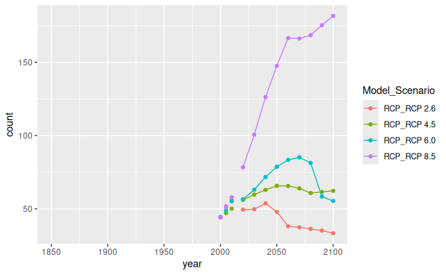

```r
emissions_regional %>%
    filter(Variable == "Emissions|CH4") %>%
    select(!Variable) %>%
    filter(Region == "Africa and Middle East") %>%
    select(!Region) %>%
    select(!Unit) %>%
    unite(Model_Scenario, c("Model", "Scenario")) %>%
    rename_with(~ str_remove(., "X"), everything()) %>%
    pivot_longer(
        cols = "1850":"2100",
        names_to = "year",
        values_to = "count"
    ) %>%
    filter(grepl("RCP", Model_Scenario)) %>%
    mutate(year = as.Date(year, format = "%Y")) %>%
    mutate(year = as.numeric(format(year, "%Y"))) %>%
    ggplot() +
    geom_point(aes(x = year, y = count, colour = Model_Scenario)) +
    geom_line(aes(x = year, y = count, colour = Model_Scenario))
```

Below is the faceted breakdown of all emissions by region. N.B.: Where the original plot shows data for “NMVOC”, it comes from the value of ”Emissions|VOC” in the dataset. Also note that I cannot get the order of the gases to match the original plot (yet). The labelling also needs some work, but the plotting itself seems to be OK.

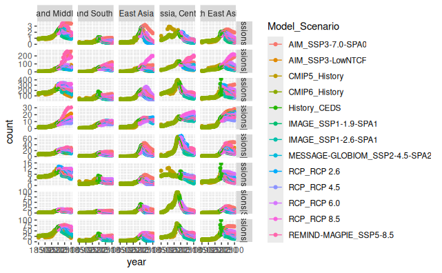

```r
emissions_type <- c("Emissions|CH4"
                  , "Emissions|BC"
                  , "Emissions|Sulfur"
                  , "Emissions|CO"
                  , "Emissions|NH3"
                  , "Emissions|VOC"
                  , "Emissions|NOx"
                  , "Emissions|OC"
                    )

emissions_regional %>%
    filter(Variable %in% emissions_type) %>%
    mutate(Variable = as.factor(Variable)) %>%
    select(!Unit) %>%
    unite(Model_Scenario, c("Model", "Scenario")) %>%
    rename_with(~ str_remove(., "X"), everything()) %>%
    pivot_longer(
        cols = "1850":"2100",
        names_to = "year",
        values_to = "count"
    ) %>%
    mutate(year = as.Date(year, format = "%Y")) %>%
    mutate(year = as.numeric(format(year, "%Y"))) %>%
    ggplot() +
    geom_point(aes(x = year, y = count, colour = Model_Scenario)) +
    geom_line(aes(x = year, y = count, colour = Model_Scenario)) +
    facet_grid(rows = vars(Variable), cols = vars(Region), scales = "free_y")
```

```r
# mutate(Variable = fct_relevel(Variable),
#          levels = c("Emissions|CH4"
#                   , "Emissions|BC"
#                   , "Emissions|OC"
#                   , "Emissions|Sulfur"
#                   , "Emissions|NOx"
#                   , "Emissions|CO"
#                   , "Emissions|VOC"
#                   , "Emissions|NH3"
#                   ))
```